# 2. Dose-Response Data Processing

gDR team

2026-06-16

2. Dose-Response Data Processing

**gDR Analysis Pipeline**

Date: 2026-06-16

Author: [gDR team](https://github.com/gdrplatform)

# 1 Introduction

This report documents the core data processing steps of the gDR pipeline. Starting with the cleaned data from Step 1, this workflow normalizes the raw viability readouts, averages technical replicates, and fits dose-response models to calculate drug sensitivity metrics. Each major step includes quality control visualizations to help assess the quality of the data and the resulting model fits.

More information about each step of the gDR pipeline can be found in the [Data processing](https://docs.google.com/document/d/10SwVs3gSMJce0TqTZTjJJAQ_YYUQ-4yGweEDgfpwnJk/edit#heading=h.f9g2z53z3gl) subsection of gDR documentation.

```r
library(qs2)
library(purrr)
library(MultiAssayExperiment)
library(data.table)
library(gDRutils)
library(gDRcore)
library(gDRplots)
```

# 2 Key Output File

This report generates the primary data object used for all downstream analysis and visualization.

## 2.1 gDR Data (in `gDR_data/` folder):

- **`gDR_mae.qs2`:** This is the main output of Step 2. It is a `MultiAssayExperiment` (MAE) object, which is a standard Bioconductor data container. This single file now contains all experimental data, organized into different “assays” (e.g., `RawTreated`, `Normalized`, `Averaged`, `Metrics`, `excess`, `scores`, etc.). This file is the required input for the **Step 3: Results Analysis** report.

# 3 Read Input Data and Identify Experiment Types

The first step is to load the prepared data from Step 1. The pipeline then automatically identifies the type of experiment for each data point (e.g., single-agent vs. combination) and splits the data into separate objects for specialized processing.

```r
wd <- getwd()
dir.create(file.path(wd, "plots"), showWarnings = FALSE, recursive = TRUE)
dir.create(file.path(wd, "gDR_data"), showWarnings = FALSE, recursive = TRUE)
data_imported <- qs_read(file.path(wd, "gDR_data", "gDR_input.qs2"))
```

```r
dt_ <- identify_data_type(data_imported)
dt_list <- split_raw_data(dt_)
```

Names of identified data types combination, single-agent.

This step involves extracting identified data into separate variables, enabling computations to be conducted independently for each data type.

```r
sa_name <- get_supported_experiments("sa")
dt_sa <- dt_list[[sa_name]]
```

```r
combo_name <- get_supported_experiments("combo")
dt_combo <- dt_list[[combo_name]]
```

# 4 Structure Data into SummarizedExperiment Objects

The data for each experiment type is now structured into `SummarizedExperiment` (SE) objects. The SE is a core data structure from Bioconductor that efficiently organizes experimental data and metadata.

A key action in this step is the mapping of control data (e.g., DMSO-treated wells) to the appropriate drug-treated wells. This mapping is essential for the normalization step that follows. The `RawTreated` and `Controls` assays are created and stored in the SE.

## 4.1 Single-agent experiment - rowData

```r
se_sa <- create_SE(dt_sa, data_type = sa_name)
generate_datatable(as.data.table(rowData(se_sa), keep.rownames = TRUE))
```

|  | rn | Gnumber | DrugName | drug_moa | Duration |
| --- | --- | --- | --- | --- | --- |
| 1 | G00103_Belvarafenib_BRAF\|RAF1\|ARAF_120 | G00103 | Belvarafenib | BRAF\|RAF1\|ARAF | 120 |
| 2 | G00104_Vemurafenib_BRAF_120 | G00104 | Vemurafenib | BRAF | 120 |
| 3 | G00105_Cobimetinib_MAP2K1\|MAP2K2_120 | G00105 | Cobimetinib | MAP2K1\|MAP2K2 | 120 |

## 4.2 Single-agent experiment - colData

```r
generate_datatable(as.data.table(colData(se_sa), keep.rownames = TRUE))
```

|  | rn | clid | CellLineName | Tissue | parental_identifier | subtype | ReferenceDivisionTime |
| --- | --- | --- | --- | --- | --- | --- | --- |
| 1 | CL00108_A-375_Skin_A-375_Melanoma_25 | CL00108 | A-375 | Skin | A-375 | Melanoma | 25 |
| 2 | CL00109_A-431_Skin_A-431_Carcinoma Squamous Cell_30 | CL00109 | A-431 | Skin | A-431 | Carcinoma Squamous Cell | 30 |
| 3 | CL00110_A2058_Skin_A2058_Melanoma_18 | CL00110 | A2058 | Skin | A2058 | Melanoma | 18 |
| 4 | CL00112_COLO 800_Skin_COLO 800_Melanoma_45 | CL00112 | COLO 800 | Skin | COLO 800 | Melanoma | 45 |
| 5 | CL00113_COLO 829_Skin_COLO 829_Melanoma_56 | CL00113 | COLO 829 | Skin | COLO 829 | Melanoma | 56 |
| 6 | CL00121_HSC-1_Skin_HSC-1_Carcinoma Squamous Cell_57 | CL00121 | HSC-1 | Skin | HSC-1 | Carcinoma Squamous Cell | 57 |
| 7 | CL00123_HT-144_Skin_HT-144_Melanoma_57 | CL00123 | HT-144 | Skin | HT-144 | Melanoma | 57 |
| 8 | CL00131_MEL-JUSO_Skin_MEL-JUSO_Melanoma_29 | CL00131 | MEL-JUSO | Skin | MEL-JUSO | Melanoma | 29 |
| 9 | CL00138_SK-MEL-28_Skin_SK-MEL-28_Melanoma_39 | CL00138 | SK-MEL-28 | Skin | SK-MEL-28 | Melanoma | 39 |
| 10 | CL00146_WM-266-4_Skin_WM-266-4_Melanoma_29 | CL00146 | WM-266-4 | Skin | WM-266-4 | Melanoma | 29 |

## 4.3 Combination experiment - rowData

```r
se_combo <- create_SE(dt_combo, data_type = combo_name)
generate_datatable(as.data.table(rowData(se_combo), keep.rownames = TRUE))
```

|  | rn | Gnumber | DrugName | drug_moa | Gnumber_2 | DrugName_2 | drug_moa_2 | Duration |
| --- | --- | --- | --- | --- | --- | --- | --- | --- |
| 1 | G00103_Belvarafenib_BRAF\|RAF1\|ARAF_G00105_Cobimetinib_MAP2K1\|MAP2K2_120 | G00103 | Belvarafenib | BRAF\|RAF1\|ARAF | G00105 | Cobimetinib | MAP2K1\|MAP2K2 | 120 |
| 2 | G00104_Vemurafenib_BRAF_G00105_Cobimetinib_MAP2K1\|MAP2K2_120 | G00104 | Vemurafenib | BRAF | G00105 | Cobimetinib | MAP2K1\|MAP2K2 | 120 |

## 4.4 Combination experiment - colData

```r
generate_datatable(as.data.table(colData(se_combo), keep.rownames = TRUE))
```

|  | rn | clid | CellLineName | Tissue | parental_identifier | subtype | ReferenceDivisionTime |
| --- | --- | --- | --- | --- | --- | --- | --- |
| 1 | CL00108_A-375_Skin_A-375_Melanoma_25 | CL00108 | A-375 | Skin | A-375 | Melanoma | 25 |
| 2 | CL00109_A-431_Skin_A-431_Carcinoma Squamous Cell_30 | CL00109 | A-431 | Skin | A-431 | Carcinoma Squamous Cell | 30 |
| 3 | CL00110_A2058_Skin_A2058_Melanoma_18 | CL00110 | A2058 | Skin | A2058 | Melanoma | 18 |
| 4 | CL00112_COLO 800_Skin_COLO 800_Melanoma_45 | CL00112 | COLO 800 | Skin | COLO 800 | Melanoma | 45 |
| 5 | CL00113_COLO 829_Skin_COLO 829_Melanoma_56 | CL00113 | COLO 829 | Skin | COLO 829 | Melanoma | 56 |
| 6 | CL00121_HSC-1_Skin_HSC-1_Carcinoma Squamous Cell_57 | CL00121 | HSC-1 | Skin | HSC-1 | Carcinoma Squamous Cell | 57 |
| 7 | CL00123_HT-144_Skin_HT-144_Melanoma_57 | CL00123 | HT-144 | Skin | HT-144 | Melanoma | 57 |
| 8 | CL00131_MEL-JUSO_Skin_MEL-JUSO_Melanoma_29 | CL00131 | MEL-JUSO | Skin | MEL-JUSO | Melanoma | 29 |
| 9 | CL00138_SK-MEL-28_Skin_SK-MEL-28_Melanoma_39 | CL00138 | SK-MEL-28 | Skin | SK-MEL-28 | Melanoma | 39 |
| 10 | CL00146_WM-266-4_Skin_WM-266-4_Melanoma_29 | CL00146 | WM-266-4 | Skin | WM-266-4 | Melanoma | 29 |

## 4.5 Quality Control: Control-to-Treatment Mapping – Single-Agent Data

This heatmap serves as a quality control check to ensure that every drug treatment in every cell line has a corresponding control value (e.g., DMSO) mapped to it. This mapping is critical for accurate data normalization.

**What to look for:** The heatmap displays drugs on the rows and cell lines on the columns. A green cell indicates that a valid control was found, and its shade of green corresponds to the number of mapped controls, as detailed in the legend. Ideally, the entire heatmap should be green. Any red cells indicate a missing control mapping, which can cause normalization errors and should be investigated.

```r
treat <- convert_se_assay_to_dt(se = se_sa,
                                assay_name = "RawTreated")
controls <- convert_se_assay_to_dt(se = se_sa,
                                   assay_name = "Controls")

# Calculate the frequency & create a heatmap
p <- heatmap_control_mapping_qc(dt_treat = treat, dt_controls = controls)
```

```r
# create link to chart
txt_link <- create_zoom_link(
  file.path(".", "plots", paste("sa_map_controls_to_treated", "svg", sep = ".")))
```

🔍 Zoom In for Details

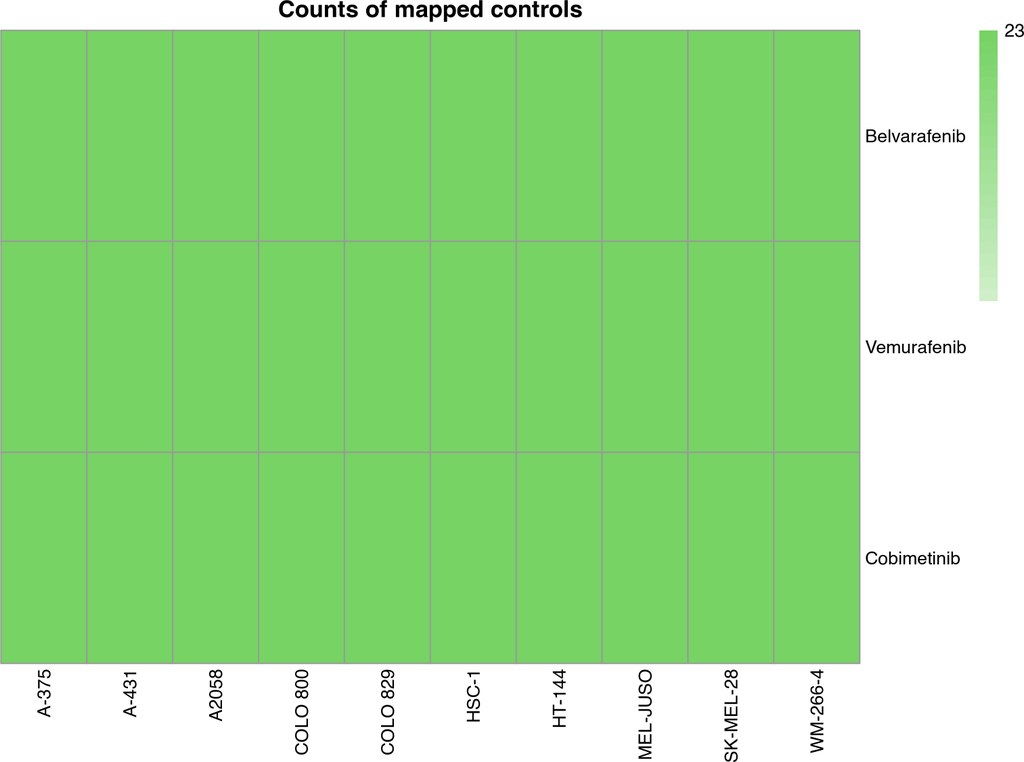

## 4.6 Quality Control: Control-to-Treatment Mapping – Combination Data

```r
treat <- convert_se_assay_to_dt(se = se_combo,
                                assay_name = "RawTreated")
controls <- convert_se_assay_to_dt(se = se_combo,
                                   assay_name = "Controls")

# Calculate the frequency & create a heatmap
p <- heatmap_control_mapping_qc(dt_treat = treat, dt_controls = controls)
```

```r
# create link to chart
txt_link <- create_zoom_link(
  file.path(".", "plots", paste("combo_map_controls_to_treated", "svg", sep = ".")))
```

🔍 Zoom In for Details

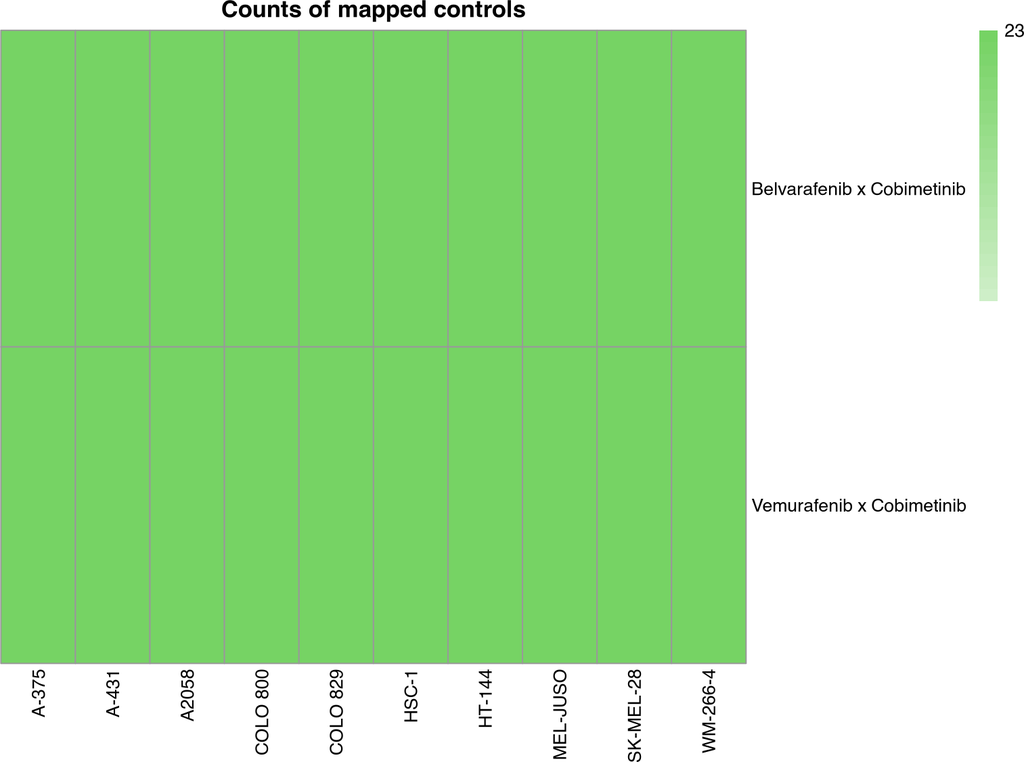

# 5 Normalize Viability Data

The raw readout values are converted to normalized values (Relative Viability or GR values) by comparing them to the mapped controls. This step creates the `Normalized` assay in the `SummarizedExperiment` object.

```r
se_sa <- normalize_SE(se_sa, data_type = sa_name)
```

```r
se_combo <- normalize_SE(se_combo, data_type = combo_name)
```

## 5.1 Quality Control: Normalized Value Distributions - Single-Agent Data

These plots show the distribution of normalized values for each cell line. This helps to check for any cell lines with unusual normalization behavior, such as extremely wide or offset distributions.

**What to look for:** For **Relative Viability (RV)**, values should typically range from 0 to 1. For **GR values**, the range can be wider, often from -1 to 1. Look for distributions that are very different from the others, as they might indicate an issue with the controls or the cell line itself.

```r
norm_data_sa <- convert_se_assay_to_dt(se = se_sa,
                                       assay_name = "Normalized",
                                       unify_metadata = TRUE,
                                       merge_additional_variables = TRUE)
cellline_vec <- sort(unique(norm_data_sa[["CellLineName"]]))
cellline_vec_names <- vapply(cellline_vec, function(i) escape_special_characters(i),
                      FUN.VALUE = character(1))

ls_plt_RV <- pmap(list(cl_name = cellline_vec),
                  plot_var_distribution_qc,
                  dt_assay = norm_data_sa,
                  normalization_type = "RV")
names(ls_plt_RV) <- cellline_vec_names
```

```r
ls_plt_GR <- pmap(list(cl_name = cellline_vec),
                  plot_var_distribution_qc,
                  dt_assay = norm_data_sa,
                  normalization_type = "GR")
names(ls_plt_GR) <- cellline_vec_names
```

### 5.1.1 Relative Viability

#### 5.1.1.1 A-375

🔍 Zoom In for Details

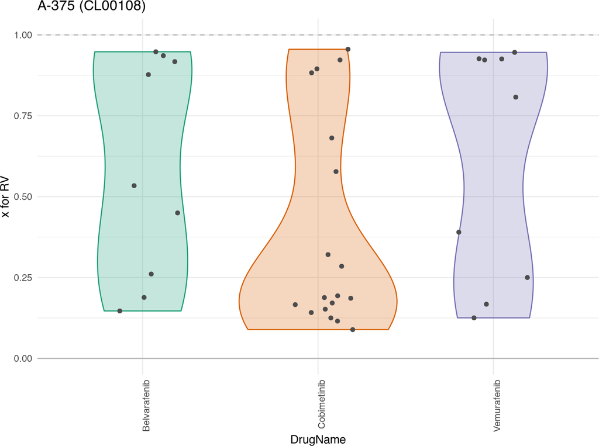

#### 5.1.1.2 A-431

🔍 Zoom In for Details

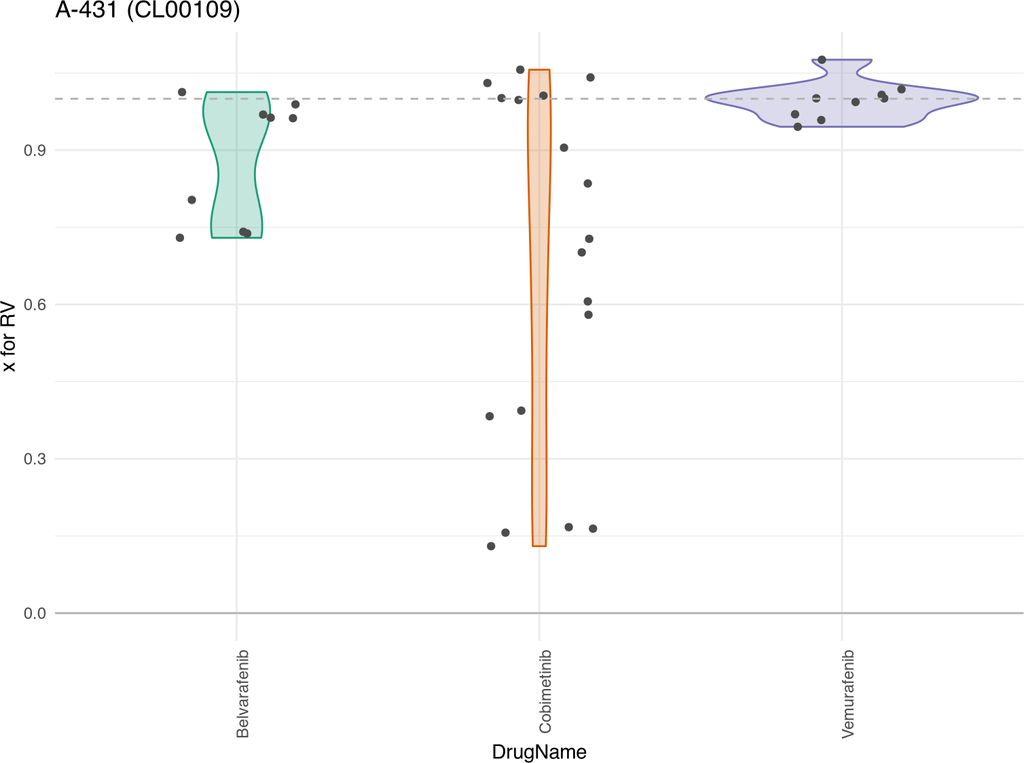

#### 5.1.1.3 A2058

🔍 Zoom In for Details

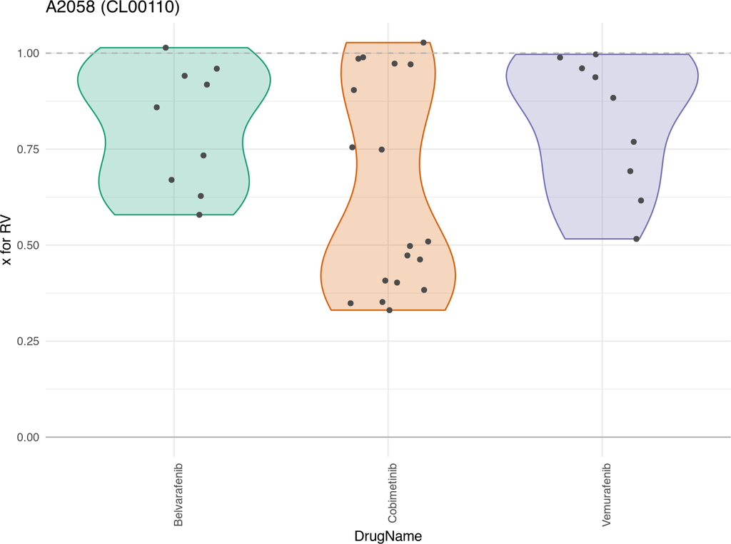

#### 5.1.1.4 COLO 800

🔍 Zoom In for Details

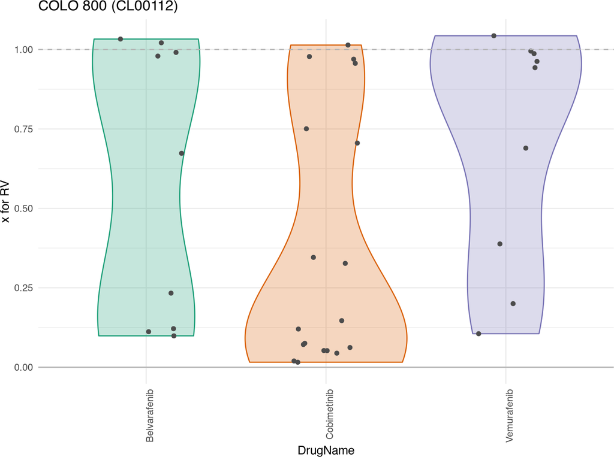

#### 5.1.1.5 COLO 829

🔍 Zoom In for Details

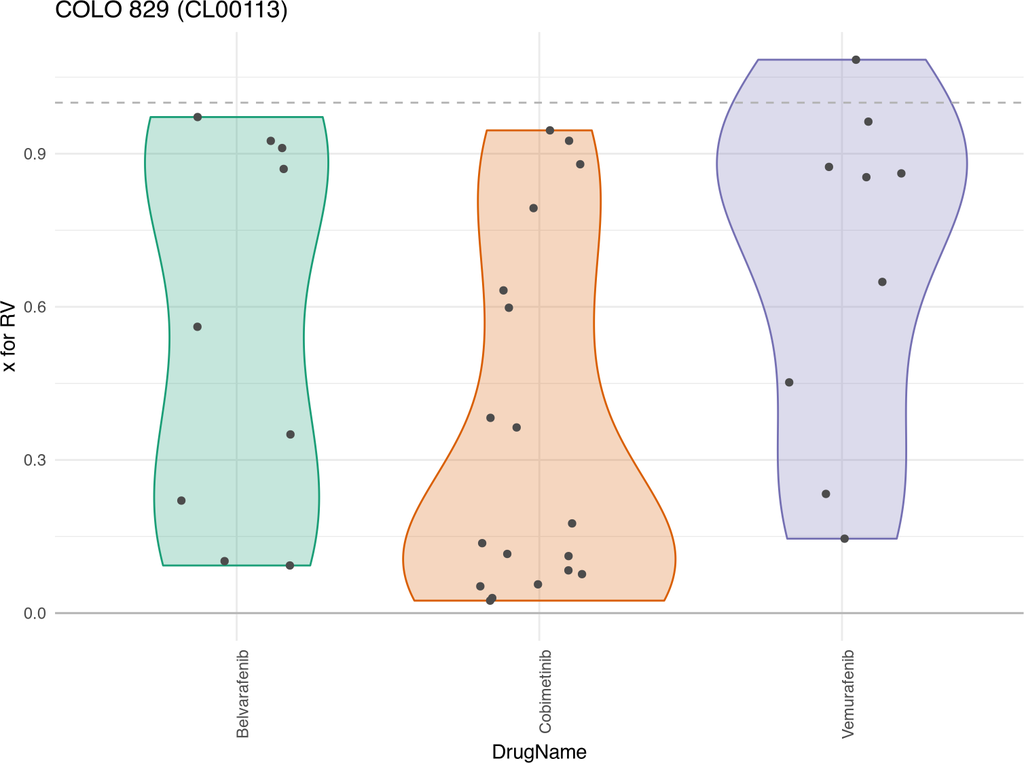

#### 5.1.1.6 HSC-1

🔍 Zoom In for Details

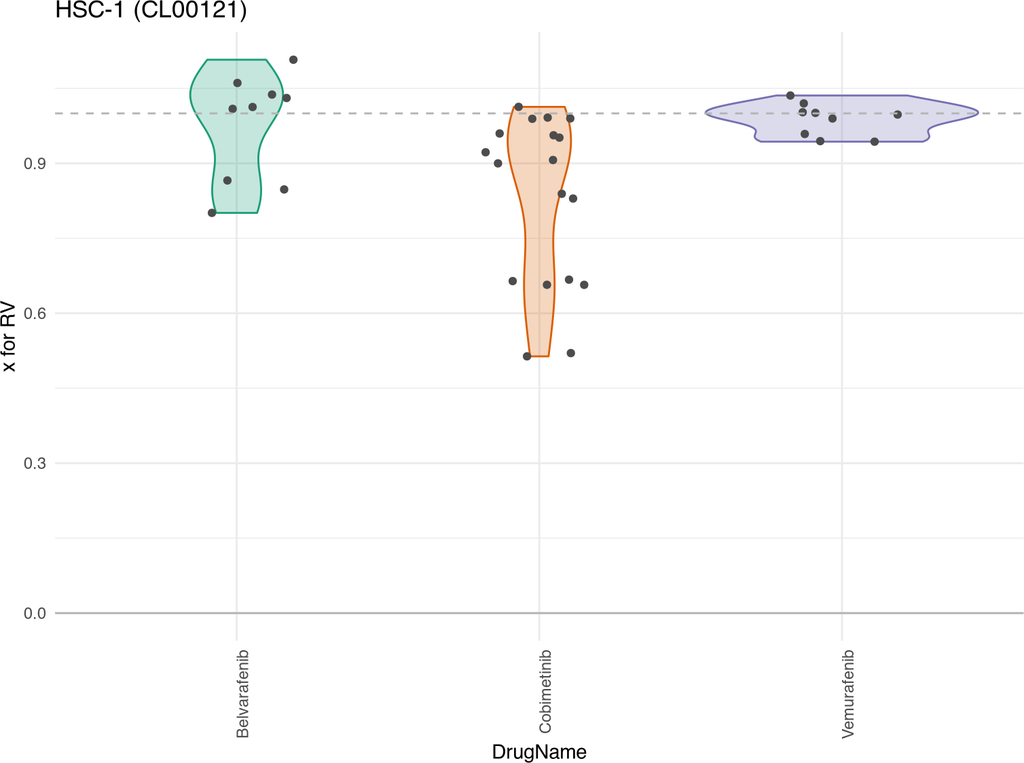

#### 5.1.1.7 HT-144

🔍 Zoom In for Details

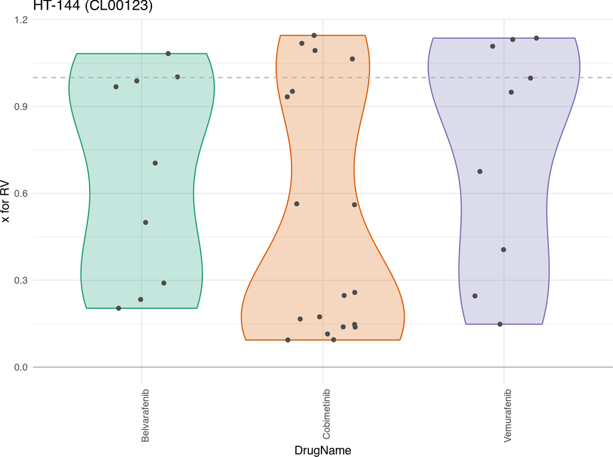

#### 5.1.1.8 MEL-JUSO

🔍 Zoom In for Details

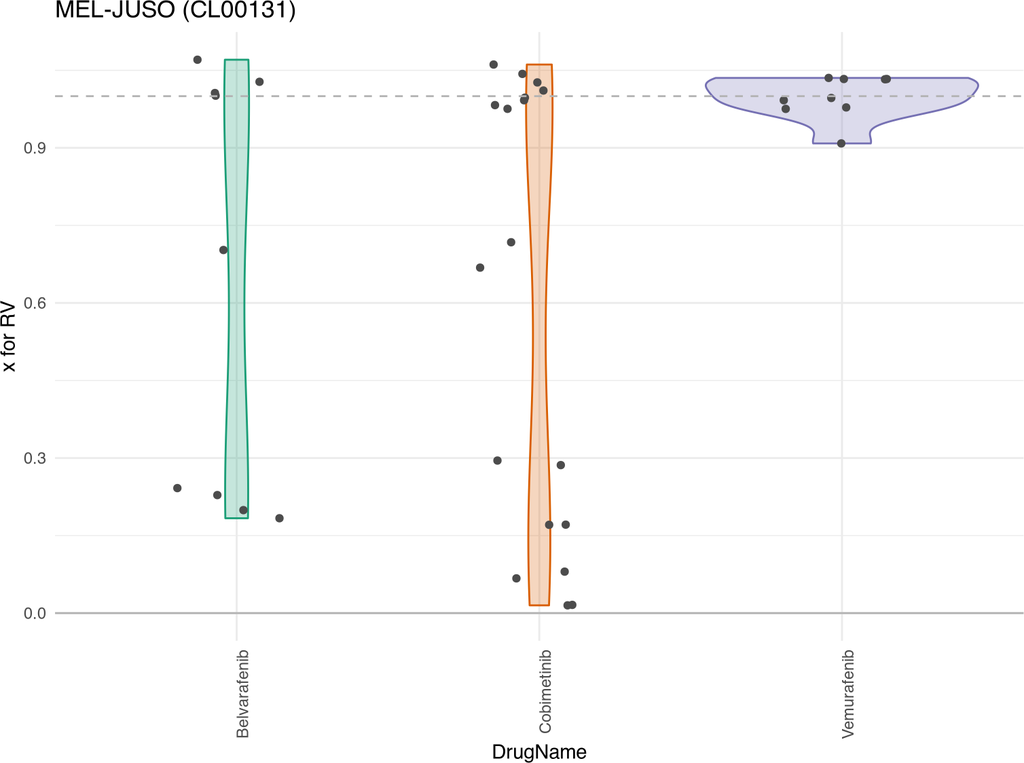

#### 5.1.1.9 SK-MEL-28

🔍 Zoom In for Details

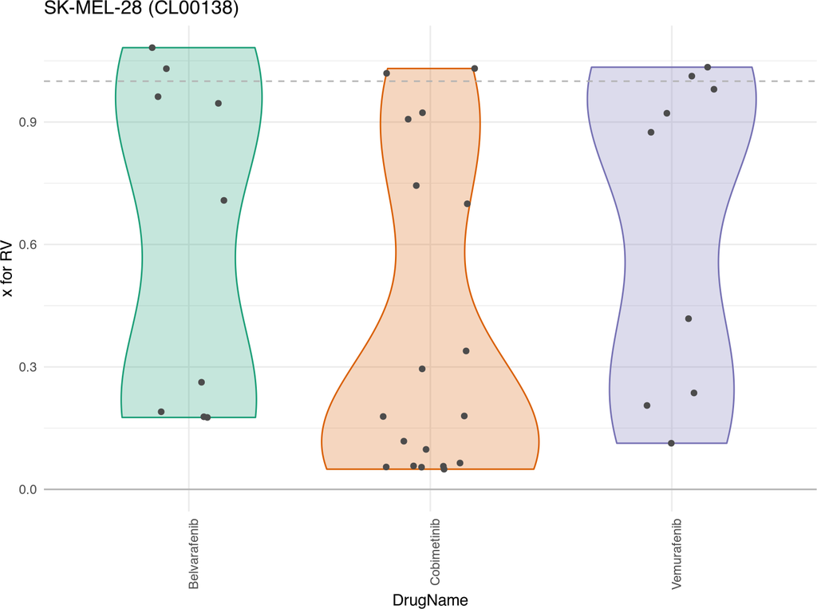

#### 5.1.1.10 WM-266-4

🔍 Zoom In for Details

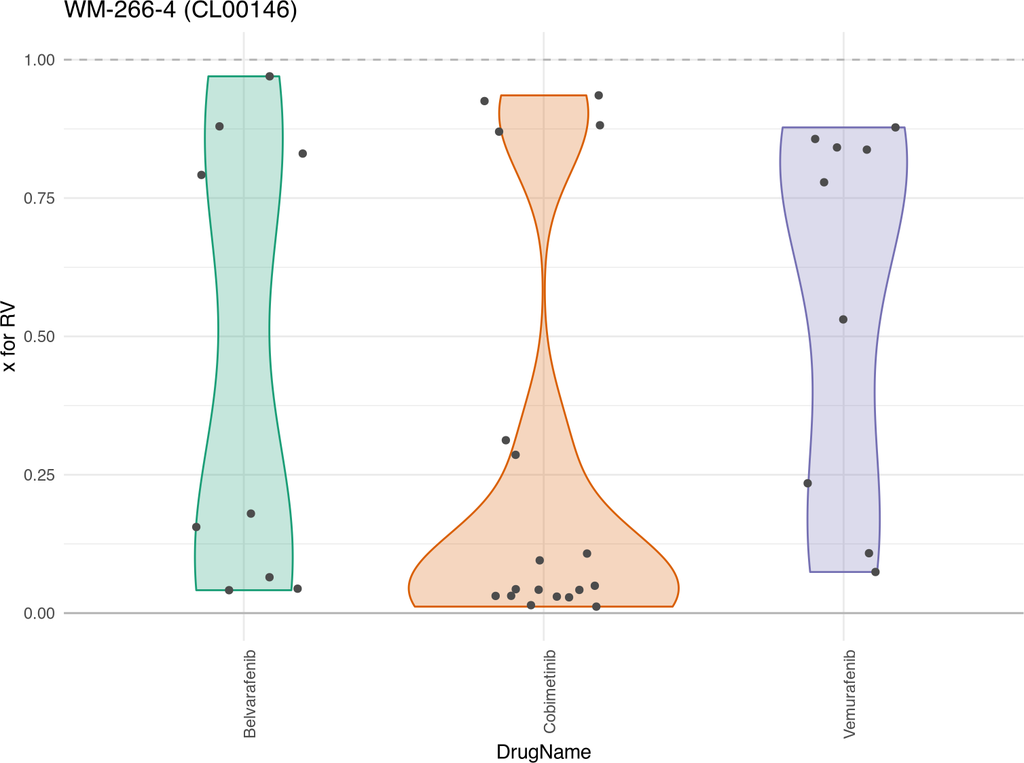

### 5.1.2 GR Value

#### 5.1.2.1 A-375

🔍 Zoom In for Details

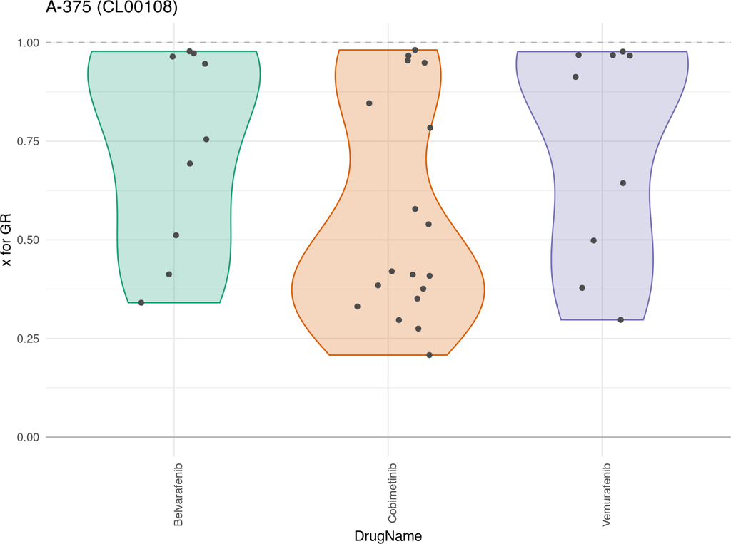

#### 5.1.2.2 A-431

🔍 Zoom In for Details

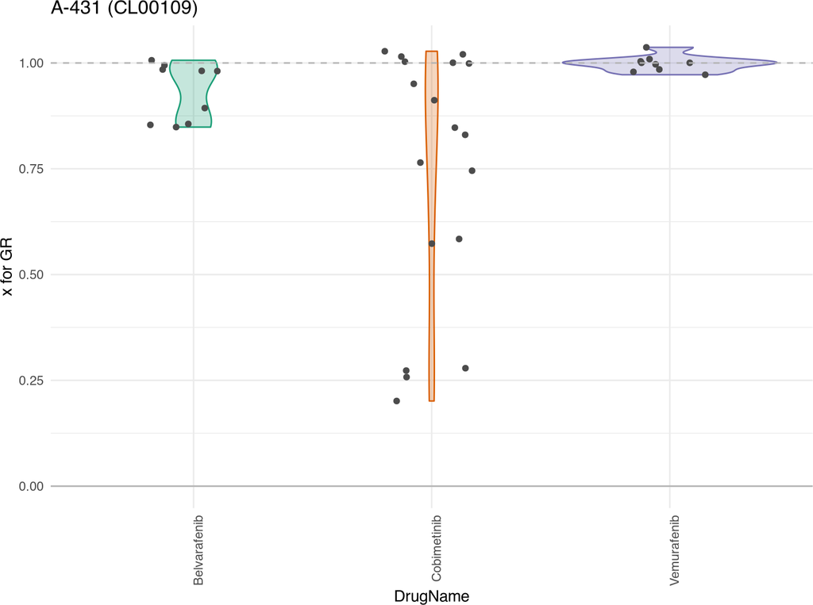

#### 5.1.2.3 A2058

🔍 Zoom In for Details

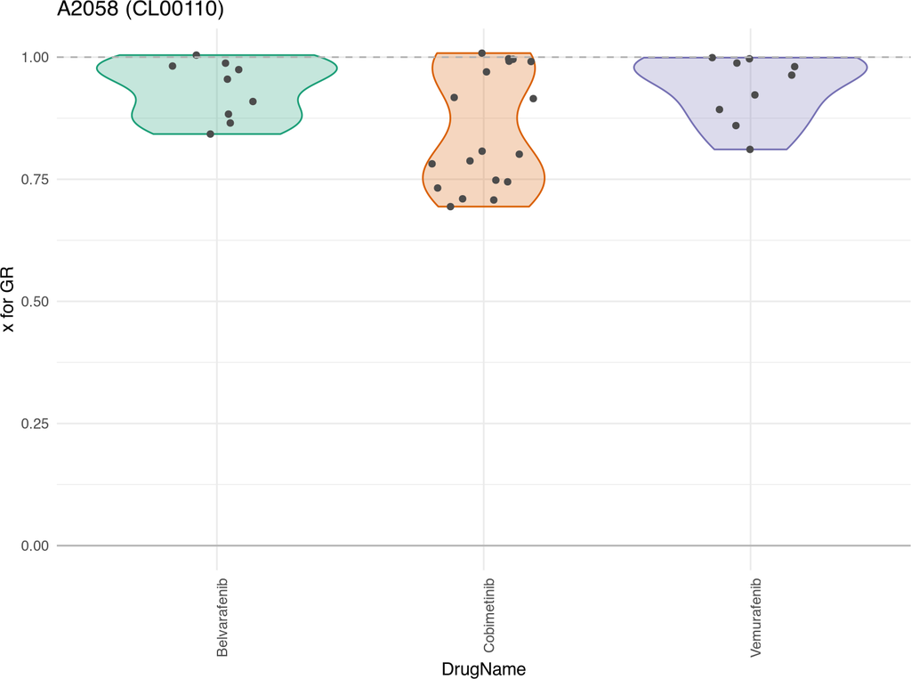

#### 5.1.2.4 COLO 800

🔍 Zoom In for Details

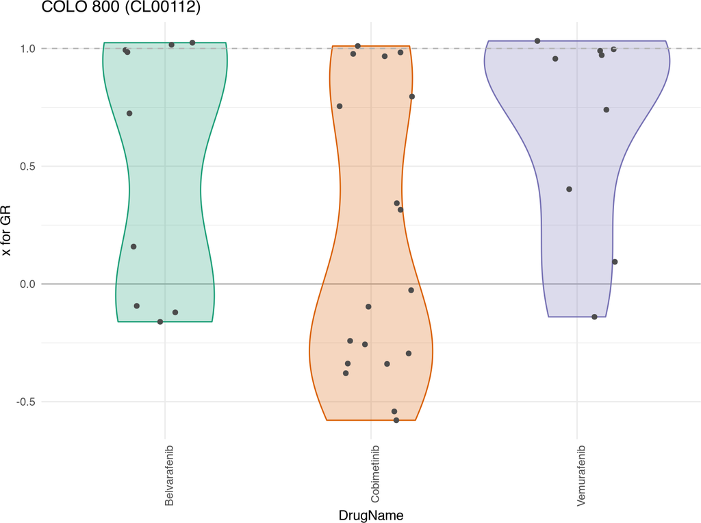

#### 5.1.2.5 COLO 829

🔍 Zoom In for Details

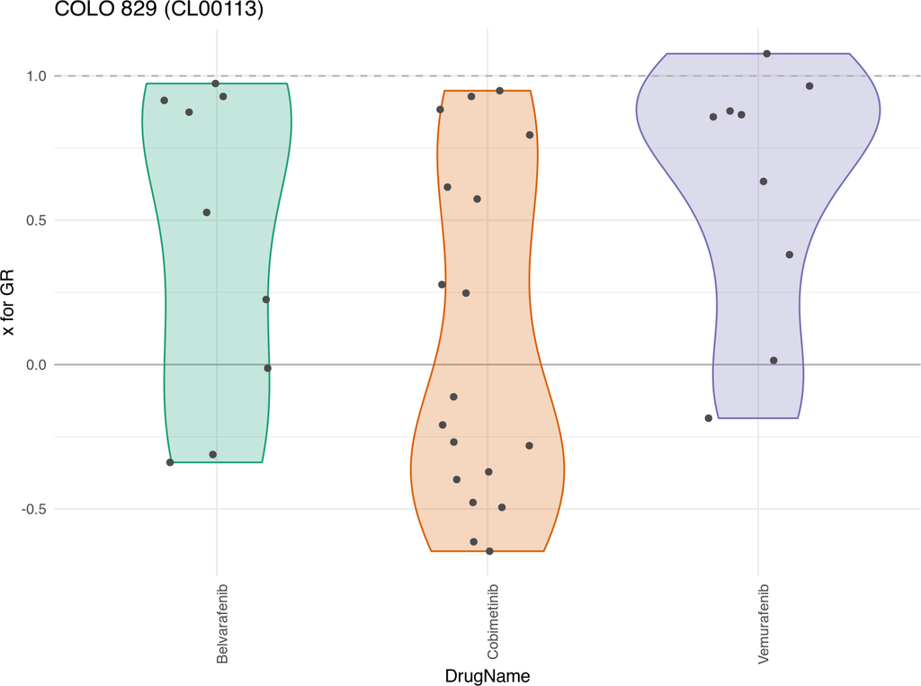

#### 5.1.2.6 HSC-1

🔍 Zoom In for Details

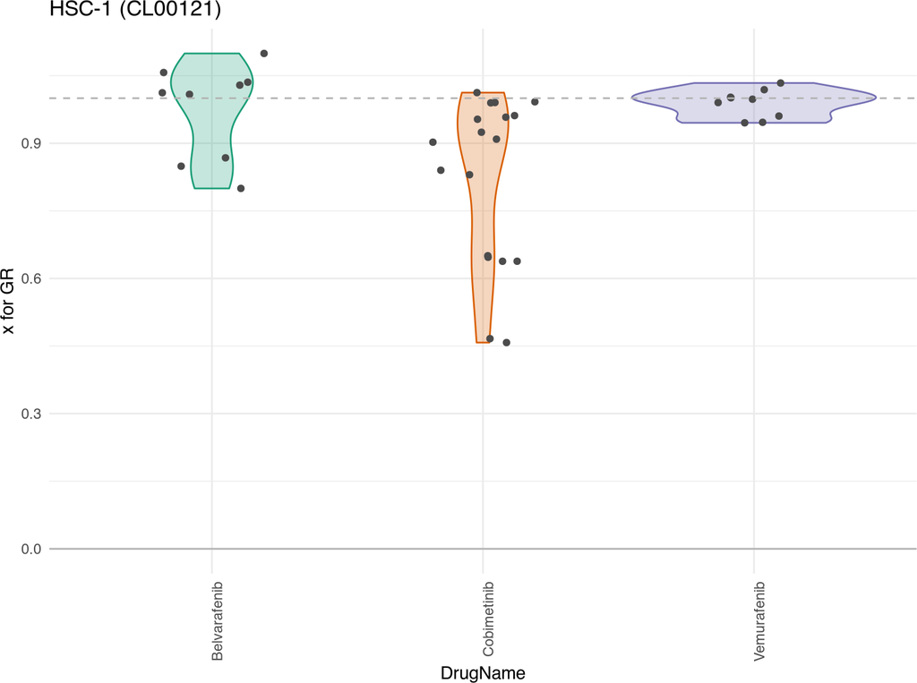

#### 5.1.2.7 HT-144

🔍 Zoom In for Details

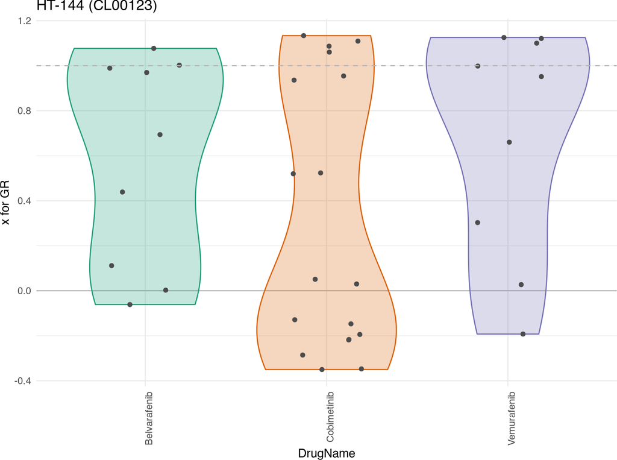

#### 5.1.2.8 MEL-JUSO

🔍 Zoom In for Details

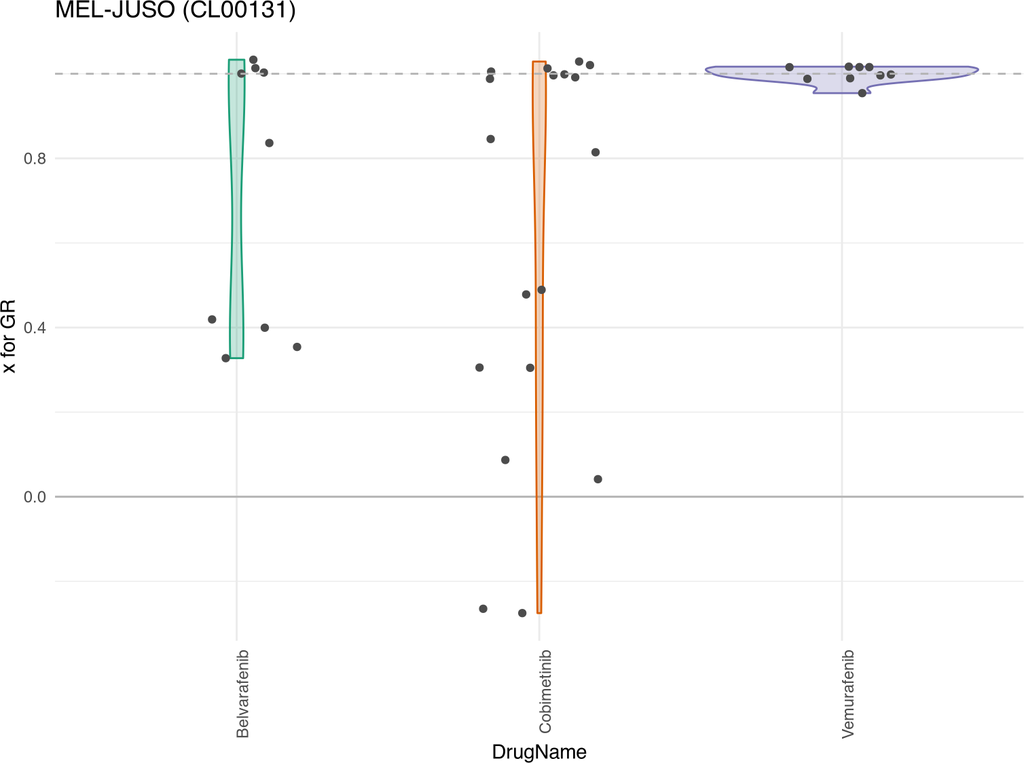

#### 5.1.2.9 SK-MEL-28

🔍 Zoom In for Details

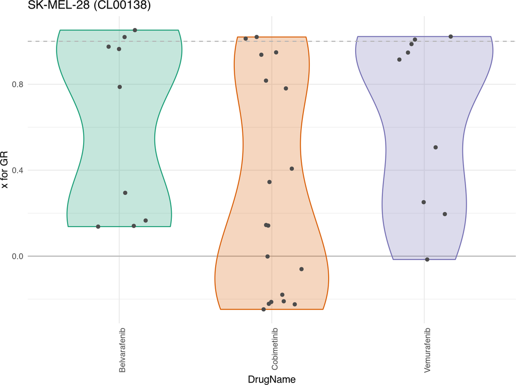

#### 5.1.2.10 WM-266-4

🔍 Zoom In for Details

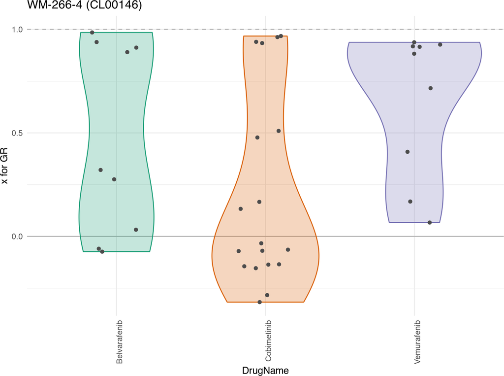

## 5.2 Quality Control: Normalized Value Distribution - Combination Data

```r
norm_data_combo <- convert_se_assay_to_dt(se = se_combo,
                                          assay_name = "Normalized",
                                          unify_metadata = TRUE,
                                          merge_additional_variables = TRUE)
cellline_vec <- sort(unique(norm_data_combo[["CellLineName"]]))
cellline_vec_names <- vapply(cellline_vec, function(i) escape_special_characters(i),
                      FUN.VALUE = character(1))

ls_plt_RV <- pmap(list(cl_name = cellline_vec),
                  plot_var_distribution_qc,
                  dt_assay = norm_data_combo,
                  normalization_type = "RV")
names(ls_plt_RV) <- cellline_vec_names
```

```r
ls_plt_GR <- pmap(list(cl_name = cellline_vec),
                  plot_var_distribution_qc,
                  dt_assay = norm_data_combo,
                  normalization_type = "GR")
names(ls_plt_GR) <- cellline_vec_names
```

### 5.2.1 Relative Viability

#### 5.2.1.1 A-375

🔍 Zoom In for Details

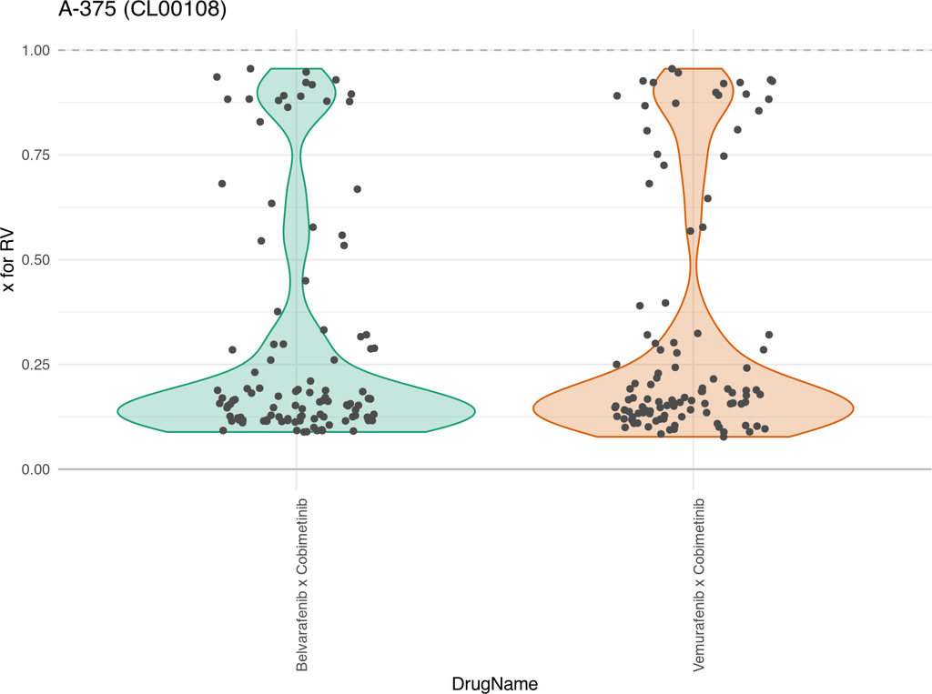

#### 5.2.1.2 A-431

🔍 Zoom In for Details

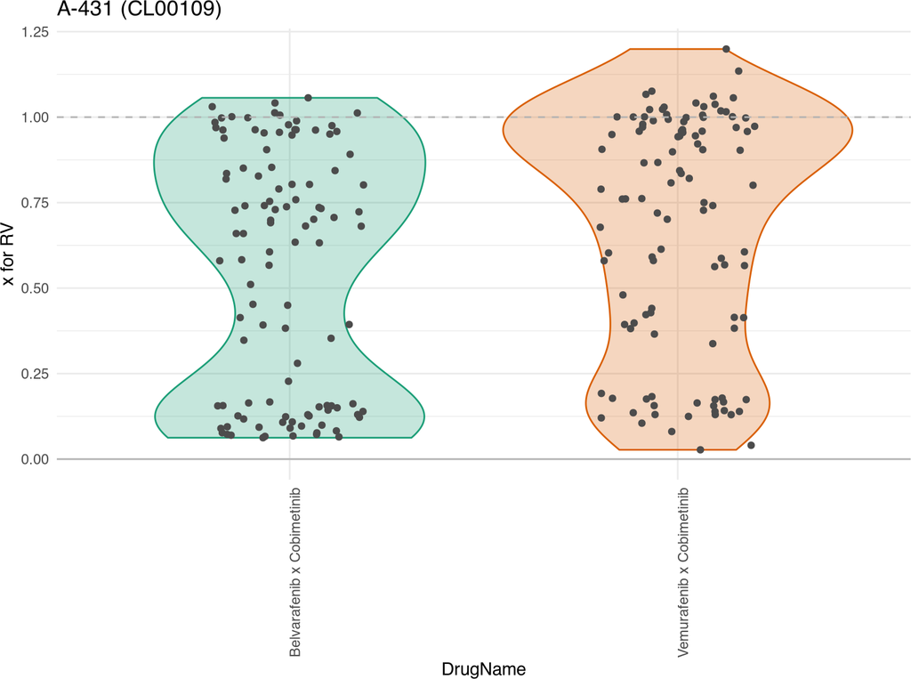

#### 5.2.1.3 A2058

🔍 Zoom In for Details

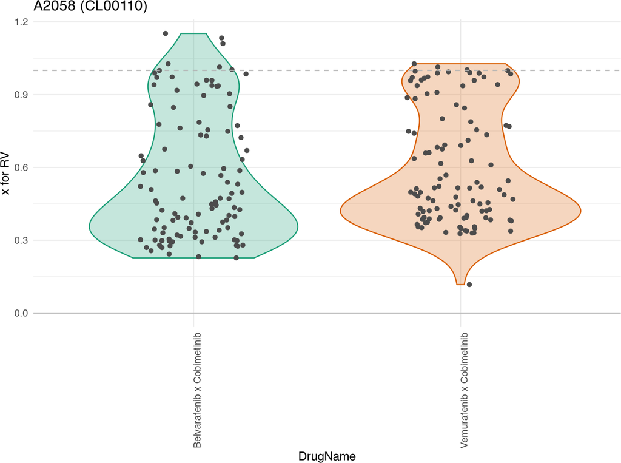

#### 5.2.1.4 COLO 800

🔍 Zoom In for Details

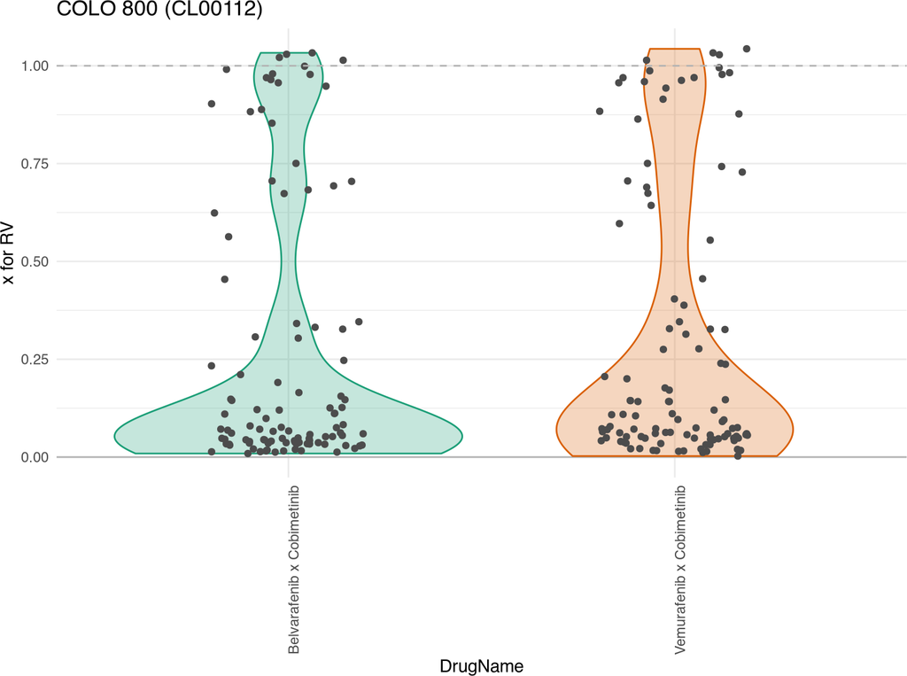

#### 5.2.1.5 COLO 829

🔍 Zoom In for Details

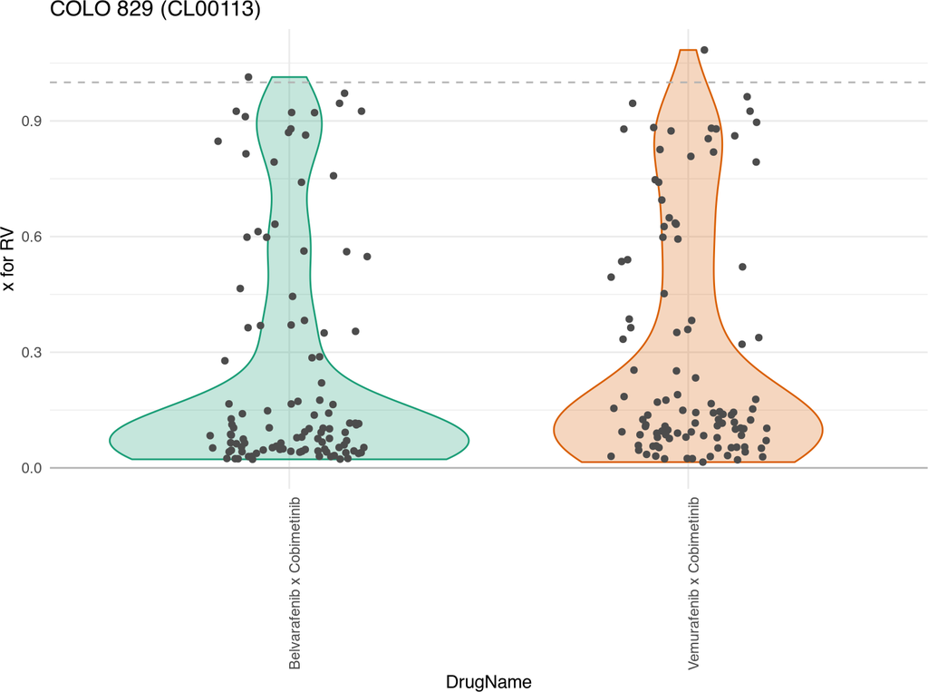

#### 5.2.1.6 HSC-1

🔍 Zoom In for Details

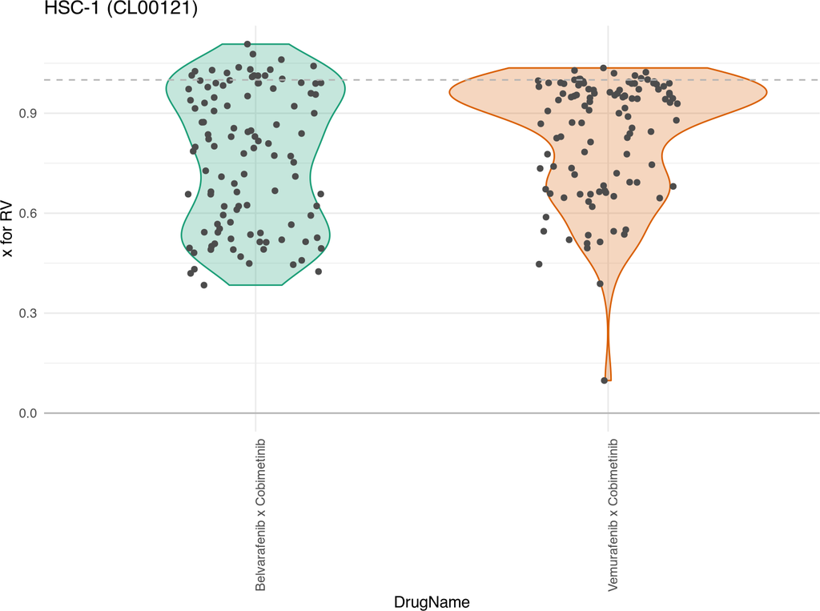

#### 5.2.1.7 HT-144

🔍 Zoom In for Details

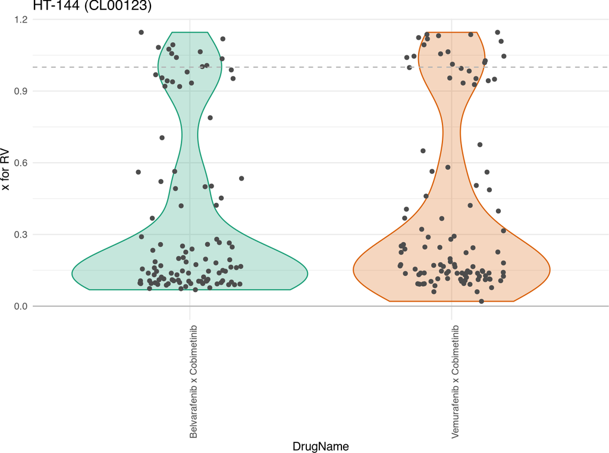

#### 5.2.1.8 MEL-JUSO

🔍 Zoom In for Details

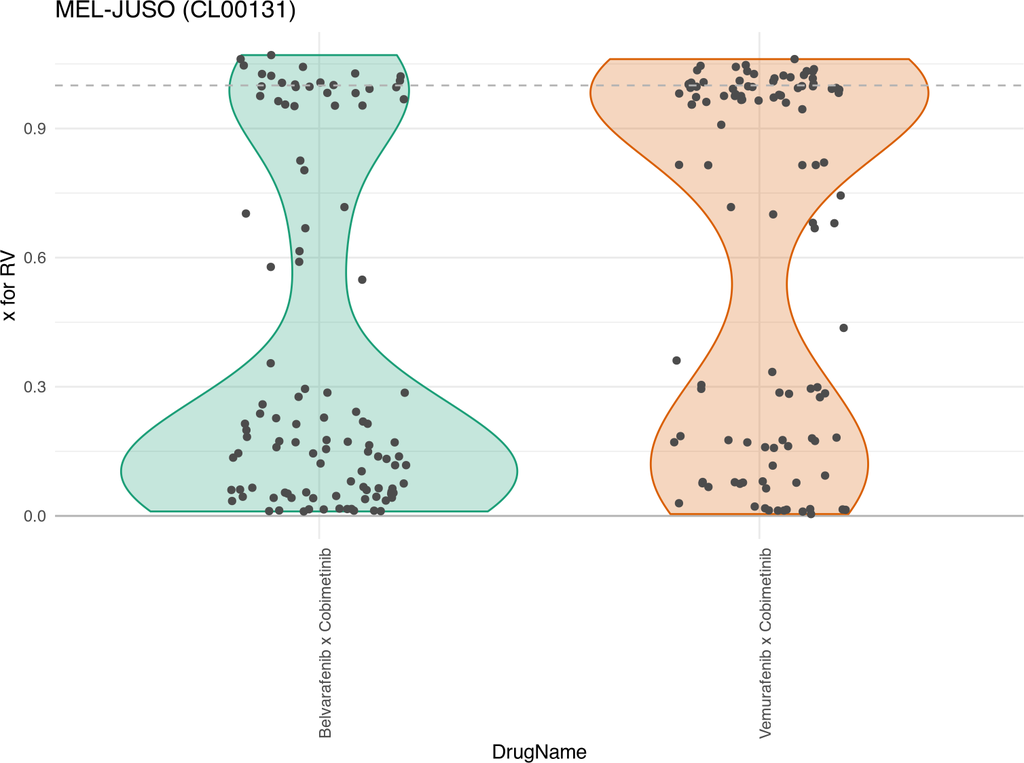